# ANLY512- Final Project

Pinky Malempati

6/17/2018

# The Quantified Self- My Travel Year

The Quantified Self is a movement that began to extract more information about oneself, especially with the help of wearable technologies to give a deeper insight into one’s lifestyle and habits. When I was presented the opportunity to work on the QS methods, I immediately learnt that it would be a great tool to understand my travel habits.

Motivation: Travel is a significant hobby of mine and I am aware that I spend a considerable amount of money on travel. Infact, I often find myself planning my monthly expenses and investments surrounding travel. In addition, the past year, I have travelled mroe than the remainder of my life put together and hence, I am interested in documenting my “Travel Year” through this project.

# Questions:

The questions I have answered through this project are as follows:

1. What time of the year do I travel spend the most on travel?
2. What purpose do I spent most of my travel bucks on?
3. Which time of the year do I travel the most?
4. Which has been the most travel intensive month of the year for me? Does it correlate with the amount spent on travel during this month?
5. Most expensive locations travelled in past year.

# Data Acquisition

In order to perform this analysis, I have looked at my credit card bills, my spreadsheets used for documenting iterinaries and travel expenses and Splitwise accounts shared with friends.

# Methods:

Data mining and manipulation- Upon extracting data from various sources and transferring into excel sheets for analysis, I performed formatting and split the expenses by month, destination, mode, purpose & activity to facilitate analysis.

In order to answer the first question,a bar plot would be the best method.

# Visualization 1:

Amount of Money Spent on Travel throughout the year

[output not shown]

[output not shown]

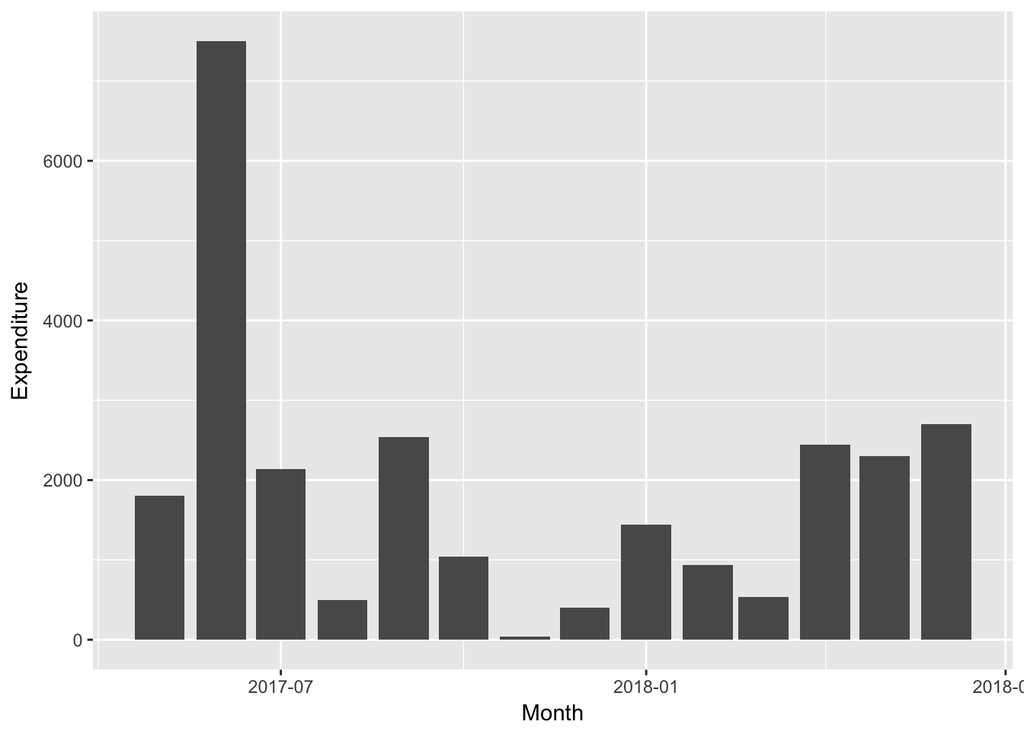

# Visualization 2:

Amount of Money Spent on Travel According to Purpose

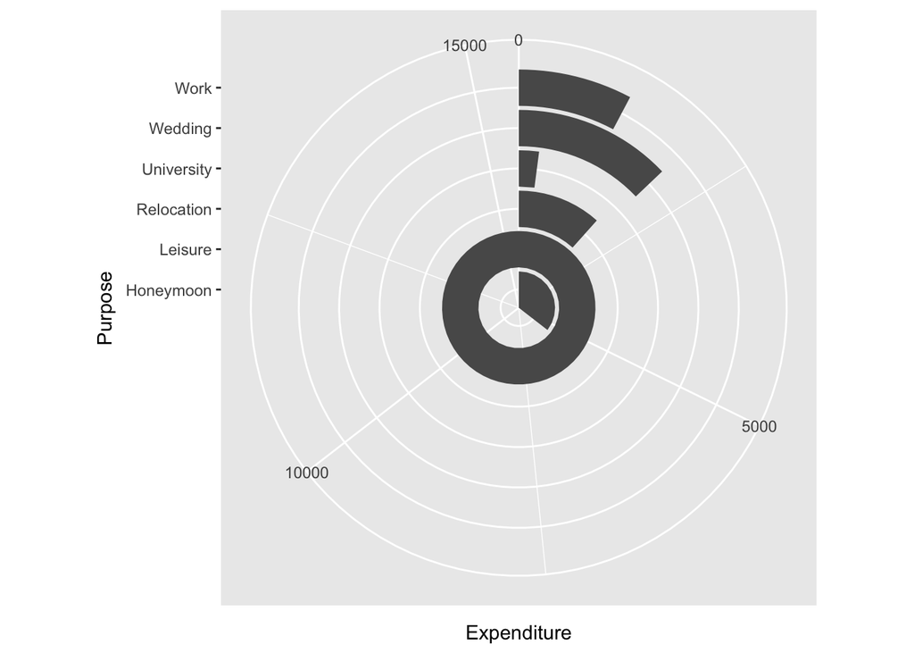

```r
Purpose<-data$Purpose
p<-ggplot(data=data,aes(Purpose,Expenditure))+stat_summary(fun.y=sum,geom="bar")
p<-p+coord_polar(theta="y",start=0,direction=1)
p
```

# Visualization 3:

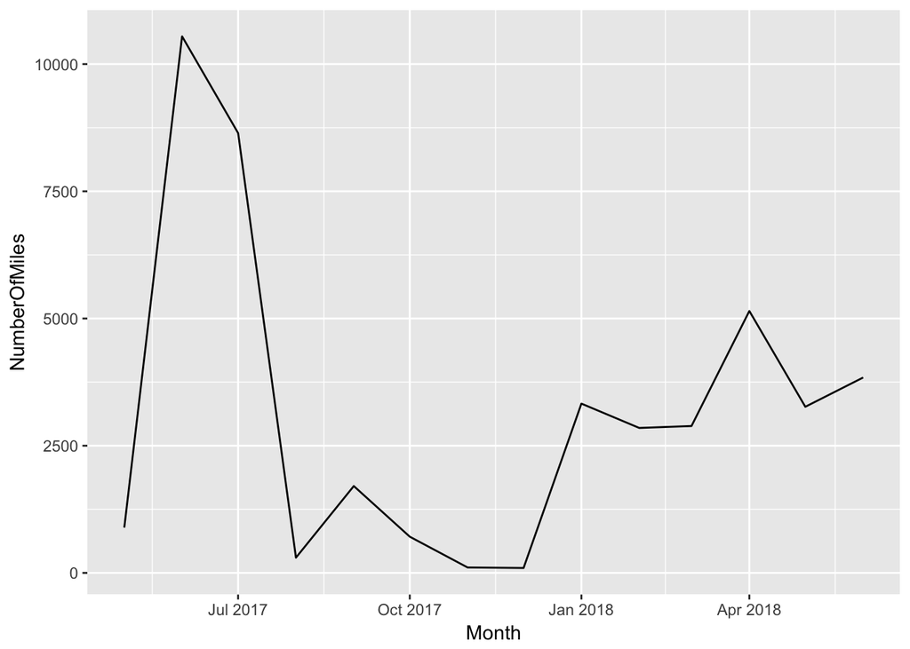

```r
NumberOfMiles<-data$NumberOfMiles
ggplot(data=data,aes(Month,NumberOfMiles))+stat_summary(fun.y=sum,geom="line")
```

# Visualization 4:

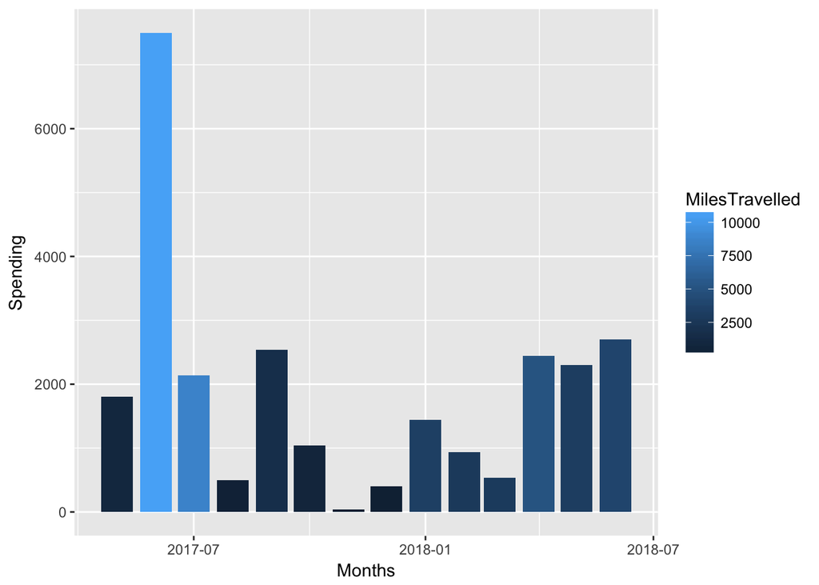

```r
mydata2<-read_excel("/Users/pinkymanoj/Desktop/TravelData2.xlsx")
data2<-data.frame(mydata2)
Spending<-data2$ExpSum
Months<-data2$MonthSum
MilesTravelled<-data2$MilesSum
ggplot(data=data2,aes(x=Months, y=Spending, fill=MilesTravelled))+geom_bar(stat="identity")
```

# Visualization 5

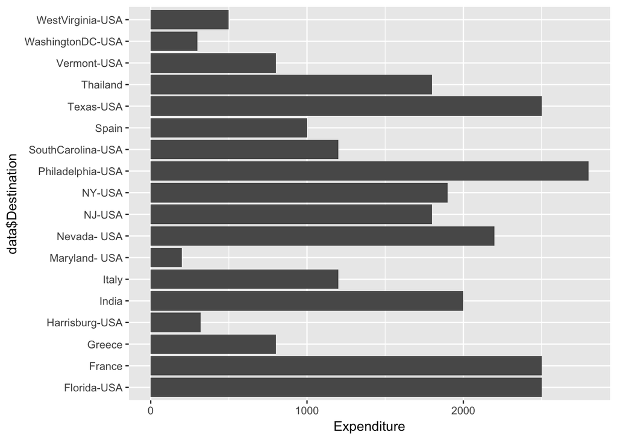

```r
ggplot(data=data,aes(data$Destination,Expenditure))+stat_summary(fun.y=sum,geom="bar")+coord_flip()
```